# ANALY 500 50 Mid-Term

Aaron An

March 12, 2016

This is my quant solution to the ANALY 500 50 Mid-Term test, which was pushed to github after the test was due and will be taken down immediately after the Spring quarter for academic integrity.

### Packages and data restructure

Load necessary pacakges to make our lives easier.

```r
library(readr)
library(dplyr)
library(ggplot2)
library(survey)
library(knitr)
```

Before the analysis part, let’s tidy up the data a little bit to make it easier to work with. The original data set is tiny and very excel-ish.

```r
midterm <- read_csv("/Users/aaronan/Analytics/MS Analytics/1. ANLY 500 50/data/midterm.csv")

midterm %>%
  select(c(1, 2:6)) %>%
  mutate(res = "r1") -> res_1

midterm %>%
  select(c(1, 7:11)) %>%
  mutate(res = "r2") -> res_2

names(res_1) = c("cid", "wt", "cs", "ppp", "s", "pppws", "res")
names(res_2) = c("cid", "wt", "cs", "ppp", "s", "pppws", "res")

res = rbind(res_1, res_2)
```

Take a look at the wide and long format. Restructured data has a column indicates resturant, which is easier for `ggplot` and generate descriptive statistics.

```r
midterm %>% head() %>% kable()
```

| cid | r1wt | r1cs | r1ppp | r1s | r1pppws | r2wt | r2cs | r2ppp | r2s | r2pppws |
| --- | --- | --- | --- | --- | --- | --- | --- | --- | --- | --- |
| 1 | 4.21 | 2 | 14.54 | Yes | 14.54 | 9.66 | 2 | 9.20 | No | NA |
| 2 | 5.55 | 5 | 17.77 | No | NA | 5.90 | 2 | 8.95 | No | NA |
| 3 | 3.02 | 2 | 16.95 | No | NA | 8.02 | 3 | 8.47 | Yes | 8.47 |
| 4 | 5.13 | 4 | 11.44 | Yes | 11.44 | 5.79 | 3 | 6.82 | Yes | 6.82 |
| 5 | 4.77 | 3 | 8.90 | Yes | 8.90 | 8.73 | 2 | 9.82 | No | NA |
| 6 | 2.34 | 1 | 15.54 | No | NA | 3.82 | 2 | 7.29 | Yes | 7.29 |

```r
res %>% head() %>% kable()
```

| cid | wt | cs | ppp | s | pppws | res |
| --- | --- | --- | --- | --- | --- | --- |
| 1 | 4.21 | 2 | 14.54 | Yes | 14.54 | r1 |
| 2 | 5.55 | 5 | 17.77 | No | NA | r1 |
| 3 | 3.02 | 2 | 16.95 | No | NA | r1 |
| 4 | 5.13 | 4 | 11.44 | Yes | 11.44 | r1 |
| 5 | 4.77 | 3 | 8.90 | Yes | 8.90 | r1 |
| 6 | 2.34 | 1 | 15.54 | No | NA | r1 |

```r
dim(midterm)
```

```
## [1] 30 11
```

```r
dim(res)
```

```
## [1] 60  7
```

R doesn’t have a default function for mode calculation, let’s make one

```r
Mode <- function(x) {
  ux <- unique(x)
  ux[which.max(tabulate(match(x, ux)))]
}
```

The calculate all the descriptive stats mentioned in the question:

```r
res %>%
  group_by(res) %>%
  summarise(var_cs = var(cs),
            sd_cs = sd(cs),
            avg_cs = mean(cs),
            mode_cs = Mode(cs)) %>% kable()
```

| res | var_cs | sd_cs | avg_cs | mode_cs |
| --- | --- | --- | --- | --- |
| r1 | 1.8206897 | 1.3493293 | 3.200000 | 4 |
| r2 | 0.4367816 | 0.6608946 | 2.333333 | 2 |

Plot the histogram of two distribution:

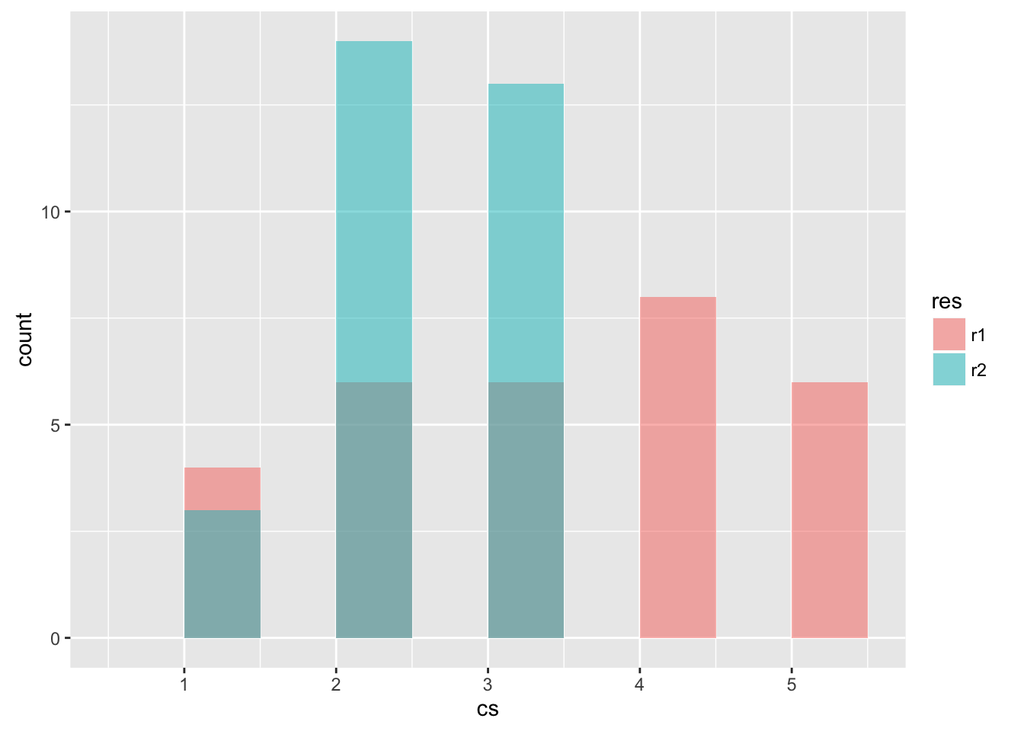

```r
ggplot(res, aes(x=cs, fill=res)) +
  geom_histogram(binwidth=.5, alpha=.5, position="identity")
```

### Q5

Use Shapiro test to determine normality (with two restaurant combined).

```r
apply(res[,c(2:4,6)], 2, shapiro.test)
```

```
## $wt
##
##  Shapiro-Wilk normality test
##
## data:  newX[, i]
## W = 0.97799, p-value = 0.3496
##
##
## $cs
##
##  Shapiro-Wilk normality test
##
## data:  newX[, i]
## W = 0.90195, p-value = 0.000155
##
##
## $ppp
##
##  Shapiro-Wilk normality test
##
## data:  newX[, i]
## W = 0.88856, p-value = 5.168e-05
##
##
## $pppws
##
##  Shapiro-Wilk normality test
##
## data:  newX[, i]
## W = 0.87155, p-value = 0.001814
```

Looks like only wait time (`wt`) is not significant, but is it nearly normal? Let’s plot it!

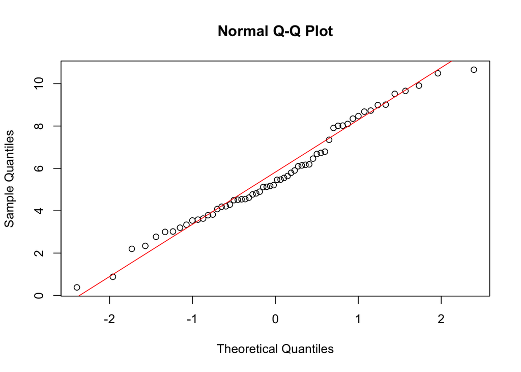

```r
qqnorm(res$wt);qqline(res$wt, col = 2)
```

Looks like normal (not deviate from normal line too far). Let’s plot it separately for two restuarants.

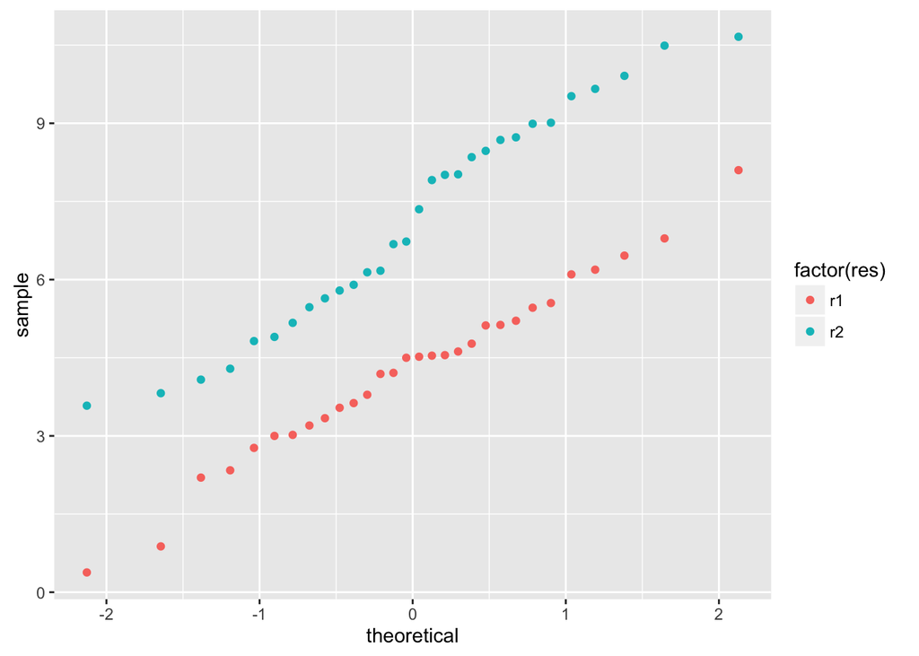

```r
ggplot(res) +
  stat_qq(aes(sample = wt, colour = factor(res)))
```

### Q6

Let’s just plot the boxplot.

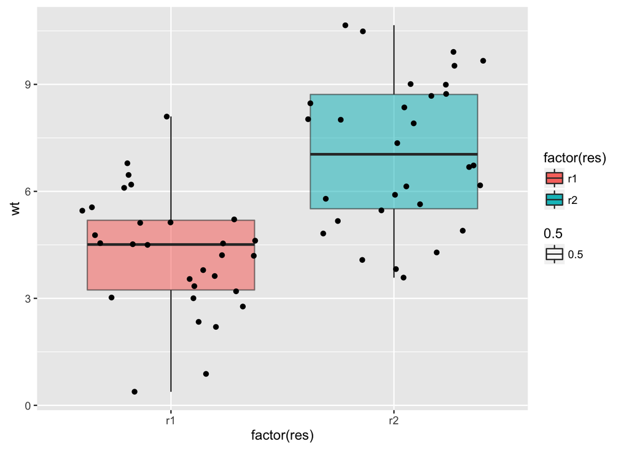

```r
ggplot(res, aes(factor(res), wt)) +
  geom_boxplot(aes(fill = factor(res), alpha =0.5))+
  geom_jitter()
```

And calculate the mean and sd

```r
res %>%
  group_by(res) %>%
  summarise(sd_wt = sd(wt),
            avg_wt = mean(wt))
```

```
## Source: local data frame [2 x 3]
##
##     res  sd_wt avg_wt
##   (chr)  (dbl)  (dbl)
## 1    r1 1.6830  4.270
## 2    r2 2.0898  7.098
```

### Q7

Two way to perform the test, depend on which data you are using:

```r
t.test(midterm$r2wt, midterm$r1wt)
```

```
##
##  Welch Two Sample t-test
##
## data:  midterm$r2wt and midterm$r1wt
## t = 5.7727, df = 55.479, p-value = 3.645e-07
## alternative hypothesis: true difference in means is not equal to 0
## 95 percent confidence interval:
##  1.84643 3.80957
## sample estimates:
## mean of x mean of y
##     7.098     4.270
```

```r
t.test(wt ~ res, data=res)
```

```
##
##  Welch Two Sample t-test
##
## data:  wt by res
## t = -5.7727, df = 55.479, p-value = 3.645e-07
## alternative hypothesis: true difference in means is not equal to 0
## 95 percent confidence interval:
##  -3.80957 -1.84643
## sample estimates:
## mean in group r1 mean in group r2
##            4.270            7.098
```

### Q8

```r
t.test(wt ~ res, data=res)$p.value < 0.05
```

```
## [1] TRUE
```

### Q10

```r
t_result = t.test(midterm$r2wt, midterm$r1wt, var.equal = F)

t_result
```

```
##
##  Welch Two Sample t-test
##
## data:  midterm$r2wt and midterm$r1wt
## t = 5.7727, df = 55.479, p-value = 3.645e-07
## alternative hypothesis: true difference in means is not equal to 0
## 95 percent confidence interval:
##  1.84643 3.80957
## sample estimates:
## mean of x mean of y
##     7.098     4.270
```

```r
t_result$p.value
```

```
## [1] 3.645385e-07
```

### Q11

```r
t_result1 = t.test(midterm$r1wt, midterm$r2wt, mu = 3.55, alternative = "less")

t_result1
```

```
##
##  Welch Two Sample t-test
##
## data:  midterm$r1wt and midterm$r2wt
## t = -13.019, df = 55.479, p-value < 2.2e-16
## alternative hypothesis: true difference in means is less than 3.55
## 95 percent confidence interval:
##       -Inf -2.008519
## sample estimates:
## mean of x mean of y
##     4.270     7.098
```

```r
t_result1$p.value < t_result$p.value
```

```
## [1] TRUE
```

### Q12

Note that in last question, in the result session shows: *true difference in means is less than 3.55*

### Q14

```r
table(res$res, res$s)
```

```
##
##      No Yes
##   r1 14  16
##   r2 16  14
```

### Q15

Use t.test to see if the specials worked.

```r
res %>%
  group_by(res, s) %>%
  summarise(avg_ppp = mean(ppp, na.rm = T))
```

```
## Source: local data frame [4 x 3]
## Groups: res [?]
##
##     res     s   avg_ppp
##   (chr) (chr)     (dbl)
## 1    r1    No 14.181429
## 2    r1   Yes 13.276250
## 3    r2    No  8.248750
## 4    r2   Yes  8.031429
```

```r
t.test(ppp ~ s, data=res_1)
```

```
##
##  Welch Two Sample t-test
##
## data:  ppp by s
## t = 0.83538, df = 26.061, p-value = 0.4111
## alternative hypothesis: true difference in means is not equal to 0
## 95 percent confidence interval:
##  -1.321842  3.132199
## sample estimates:
##  mean in group No mean in group Yes
##          14.18143          13.27625
```

```r
t.test(ppp ~ s, data=res_2)
```

```
##
##  Welch Two Sample t-test
##
## data:  ppp by s
## t = 0.56995, df = 26.654, p-value = 0.5735
## alternative hypothesis: true difference in means is not equal to 0
## 95 percent confidence interval:
##  -0.5655188  1.0001617
## sample estimates:
##  mean in group No mean in group Yes
##          8.248750          8.031429
```

Both test are not significant, accept H-null, no effect of the special thing.